# ridesharing.api

01.01.2019

Version dev

# 1 Einleitung

Der Mitfahrmarkt in Deutschland ist stark fragmentiert und hierdurch für die Nutzer der vielfältigen Vermittlungsangebote nicht ausreichend transparent. Fahrer und Mitfahrer finden zum Teil nicht oder nur mit großem Zeitaufwand zusammen. Dieses Problem wollen wir mit einem offenen Datenstandard und der Perspektive auf ein gemeinsames Meta-Such-Portal angehen.

## 1.1 Zielsetzung

Dass Mobilität durch eine bessere Vernetzung verschiedener Verkehrsmittel schneller, komfortabler und umweltfreundlicher werden kann ist mittlerweile allgemeiner Konsens. Doch an dem „wie“ scheiden sich oft die Geister. Eines der Kernprobleme ist, dass fast jeder Anbieter von Mobilitätslösungen in Deutschland einen anderen Datenstandard nutzt.

Dies ist auch imbeim Mitfahrmarkt nicht anders. Dabei wäre gerade der Mitfahrmarkt besonders auf eine Vernetzung angewiesen, wie ein früheres Forschungsprojekt und die darauf folgenden Entwicklungen des Mitfahrmarkts in den letzten Jahren verdeutlicht haben. Die große Anzahl an Vermittlungsangeboten erhöht den Aufwand für das Zusammenfinden und vermindert mögliche Vermittlungserfolge. Ein Metaportal könnte dieses roblem lösen, doch dies ist nur möglich, wenn die Daten mindestens strukturiert, im besten Fall in einem einheitlichen Datenstandard vorliegen.

Vergleichbar ist die Situation mit der menschlichen Kommunikation: Möchte man komplexe Informationen austauschen, so ist es zwangsweise erforderlich, dass man die Sprache des Anderen beherrscht. Ansonsten ist Kommunikation nur mit hohem Aufwand und dem Verlust vieler Details möglich. Genauso verhält es sich in der Mobilität: Eine gut funktionierende Vernetzung gibt es nur mit gemeinsamer Sprache, also einem gemeinsamen Datenstandard.

Wichtig ist, dass es sich dabei um einen offenen Datenstandard handelt, der ohne Lizenzgebühren einsehbar und nutzbar ist. Die aktuelle unbefriedigende Situation ist unter anderem auf geschlossene Standards zurückzuführen – ein Datenaustausch zwischen den Plattformen findet zur Zeit nahezu nicht statt. Das Internet selbst sollte dabei Vorbild sein: Nur durch die vielen offenen Standards ist die Vernetzung möglich geworden. Und auch hier wieder gilt die Analogie zur menschlichen Sprache: Die Idee, für jede Nutzung eines deutschen Wortes eine Lizenzgebühr zu verlangen, würde zu Recht als völlig absurd abgetan werden.

## 1.2 Nutzungsszenarien

Ein Datenstandard für den Mitfahrmarkt hat zahlreiche Anwendungen. Einige davon sollen hier exemplarisch vorgestellt werden.

## 1.3 Marktumfeld

Mit über 50 Mitfahrbörsen und Mitfahrapps gibt es eine Vielzahl an Angeboten. Unter den Plattformen gibt es nur in Einzelfällen einen Datenaustausch. Da die Anzahl der Fahrerinnen und Fahrer eher begrenzt ist, gibt es viele recht leere Mitfahrbörsen. Mitfahrerinnen und Mitfahrer haben daher häufig das Problem, dass Suchen nach Mitfahrgelegenheiten sehr mühsam sind, da man etliche Börsen durchgehen muss, um etwas zu finden.

FahrerInnen und MitfahrerInnen verlieren sich schlicht auf der Vielzahl nicht vernetzter Angebote, und dies sorgt für ein Schrumpfen des gesamten Marktes.

### 1.3.1 Metaportal

Aktuell verlieren sich Fahrt-Anbieter und Mitfahrer von Mitfahrgelegenheiten auf den über 50 Mitfahrportalen, Apps u.v.m.. Darüber hinaus gibt es noch zahlreiche interne und / oder analoge Systeme wie Mitfahrbänke.

Es bräuchte also eine spezielle Suchmaschine, welche Zugriff auf alle Daten aller Mitfahrbörsen hat und so Nutzer schnell über alle Plattformen hinweg Fahrten suchen können. Diese Suchmaschine wäre das schon mehrfach zuvor angesprochene Meta-Portal.

Ein Meta-Portal würde von möglichst vielen Mitfahr-Plattformen Daten aggregieren und zusammenfügen. Es hätte lediglich Fahrt-Informationen und wäre so eine rein anonyme Suchmaschine: Die Kontaktaufnahme würde weiterhin auf der Plattform geschehen, in welcher der Fahrer die Fahrt eingestellt hat.

Darüber hinaus könnte das Metaportal die aggregierten Daten normalisieren, automatisiert veredeln und wiederum via ridesharing.api zur Verfügung stellen. Dies würde den Aufwand einer Vernetzung zwischen den Portalen reduzieren, da Fehler einmal auf der Metaplattform statt bei jedem Datenimport einer Mitfahrbörse ausgebügelt werden können. Außerdem könnte das Meta-Portal dieselben Daten auch über moderne Schnittstellen wie z.B. Websockets bereitstellen, selbst wenn das ursprüngliche Portal dies nicht kann.

### 1.3.2 Multimodalität

Ridesharing funktioniert dann ganz besonders gut, wenn man es mit dem öffentlichen Nahverkehr verbindet. Denn gerade, wenn MitfahrerInnen zwischendurch dazusteigen wollen, hängt vom Wahl des Treffpunktes die Effizienz der gesamten Fahrt ab. Bei Langstrecken-Fahrten lohnt es sich oft, einen Treffpunkt außerhalb der Innenstadt zu wählen. Und auch bei Pendelfahrten lohnt es sich, den Mitfahrenden nicht unbedingt von zu Hause aus abzuholen.

Moderne Routing-Engines bringen alles mit, um Mitfahrgelegenheiten und ÖPNV optimal zu verknüpfen. Um jedoch zu funktionieren, brauchen Routing-Engines standardisierte Rohdaten. Viele Routing-Engines funktionieren mit GTFS sowie GTFS-RT, so dass ein Datenstandard für Mitfahrgelegenheiten bestmöglich in GTFS umformbar sein sollte.

### 1.3.3 Export von Profildaten

Da es zahlreiche Ridesharing-Plattformen gibt, sollte es eine Möglichkeit geben, dass Nutzer ihre persönlichen Einstellngen und Präferenzen auf einer Plattform exportieren und auf einer anderen importieren können. Mit der DSGVO ist dieses eh wünschenswerte Feature verpflichtend geworden.

Vielfach scheitert dieses Anliegen aber noch an dem Datenformat, da man aktuell eher CSVs und Textdateien statt strukturierte Daten bekommt. Dies kann die ridesharing.api ändern, indem es ein JSON-Datenmodell definiert und so die Plattformen in weiten Teilen untereinander kompatibel macht.

Praktisch sähe das dann so aus, dass ein Nutzer beim Export seiner Nutzerdaten eine einzige JSON-Datei herunterladen könnte. Wenn die Ziel- Plattform das unterstützt, könnte der Nutzer die Datei dann auf der Ziel- Plattform hochladen und hätte so ganz einfach sämtliche Einstellungen übertragen.

## 1.4 Bestehende Standards

Es gibt bereits eine Reihe an Datenstandards, die sich im Umfeld des Ridesharing-Marktes bewegen. Grob lassen sich diese in zwei Kategorien einsortieren: Spezielle Ride-Sharing-Schnittstellen, welche die besonderen Bedürfnisse des Ridesharings berücksichtigen, und allgemeine Mobilitäts-Daten-Standards, welche durch eine höhere Abstraktion Kompatibilität zu anderen Mobilitätsformen herstellen. Eine Auswahl:

- Dycapo ist das Ergebnis einer Bachelor-Arbeit, welche ein abstraktes Datenmodell auf JSON-Basis definiert und einen vollwertigen Server mit vielen Aspekten des Meta-M-Mitfahrportals entwickelt hat. [Die Dokumentation und der Code sind öffentlich auf Github einsehbar](https://github.com/dgraziotin/dycapo).
- Das oben erwähnte Forschungsprojekt hat ein sehr umfangreiches XML-Datenmodell spezifiziert, welches viele wichtige Aspekte anspricht, aber mittlerweile aufgrund seines Alters von ca. 10 Jahren einer Aktualisierung bedarf .
- Eine Reihe an plattform-spezifischen Schnittstellen bilden ebenfalls Mitfahrgelegenheiten ab. Diese werden hier aus Neutralitätsgründen nicht aufgeführt. Umso mehr wird eingeladen, diese auf Github zu sammeln und zu diskutieren .
- Die Datenstandards [GTFS](https://developers.google.com/transit/gtfs/) und [GTFS-RT](https://developers.google.com/transit/gtfs-realtime/) bieten eine gute und realistische Möglichkeit, Ridesharing-Daten mit weiteren Mobilitätsdaten wie zum Beispiel dem ÖPNV zu verknüpfen. Außerdem ist GTFS ein Standard-Import-Format für Open-Source-Routing-Engines.
- Es sollte darauf geachtet werden, Kompatibilität zum zukünftigen europäischen Datenstandard für Nahverkehrs-Daten [NeTEx](http://netex-cen.eu/) zu gewährleisten, da abzusehen ist, dass in diesem Umfeld Daten und Software entstehen wird, welche auch für den Mitfahr-Markt von Interesse sind.

## 1.5 Nomenklatur

### 1.5.1 Zwingende, empfohlene und optionale Anforderungen

Diese Spezifikation nutzt **müssen**, **können** und **sollten** in einer eindeutig definierten Art und Weise. Diese ist angelehnt an die Definitionen der Begriffe MUST, SHOULD und MAY (bzw. MUST NOT, SHOULD NOT und MAY NOT) aus RFC2119.[^1]

Die Bedeutung im Einzelnen:

**müssen**/**muss** bzw. **zwingend**:**

Die Erfüllung einer so gekennzeichneten Anforderung ist zwingend erforderlich.

Die Entsprechung in RFC2119 lautet "MUST", "REQUIRED" oder "SHALL".

**nicht dürfen**/**darf nicht**:**

Dieses Stichwort kennzeichnet ein absolutes Verbot.

Die Entsprechung in RFC2119 lautet "MUST NOT" oder "SHALL NOT".

**sollten**/**sollte** bzw. **empfohlen**:**

Mit dem Wort **sollten** bzw. **sollte** sind empfohlene Anforderungen gekennzeichnet, die von jeder Implementierung erfüllt werden sollten. Eine Nichterfüllung ist als Nachteil zu verstehen, beispielsweise weil die Nutzerfreundlichkeit dadurch Einbußen erleidet, und sollte daher sorgfältig abgewogen werden.

Die Entsprechung in RFC2119 lautet "SHOULD" oder "RECOMMENDED".

**sollten nicht**/**sollte nicht** bzw. **nicht empfohlen**:**

Diese Formulierung wird verwendet, wenn unter gewissen Umständen Gründe existieren können, die ein bestimmtes Verhalten akzeptabel oder sogar nützlich erscheinen lassen, jedoch die Auswirkung des Verhaltens vor einer entsprechenden Implementierung verstanden und abgewogen werden sollten.

Die Entsprechung in RFC2119 lautet "SHOULD NOT" oder "NOT RECOMMENDED".

**dürfen**/**darf** bzw. **optional**:**

Mit dem Wort **dürfen** bzw. **darf** oder **optional** sind optionale Bestandteile gekennzeichnet. Ein Anbieter könnte sich entscheiden, den entsprechenden Bestandteil aufgrund besonderer Kundenanforderungen zu unterstützen, während andere diesen Bestandteil ignorieren könnten. Implementierer von Clients oder Servern **dürfen** in solchen Fällen **nicht** davon ausgehen, dass der jeweilige Kommunikationspartner den entsprechenden, optionalen Anteil unterstützt.

Die Entsprechung in RFC2119 lautet "MAY".

### 1.5.2 Geschlechterspezifische Begrifflichkeiten

Um bei Begriffen wie Nutzer, Anwender, Betreiber etc. die sonst übliche Dominanz der männlichen Variante zu vermeiden, werden in diesem Dokument männliche und weibliche Varianten gemischt. Gemeint sind in allen Fällen Personen jeglichen Geschlechts.

### 1.5.3 Codebeispiele

Die in diesem Dokument aufgeführten Codebeispiele dienen der Veranschaulichung der beschriebenen Prinzipien. Es handelt sich um frei erfundene Daten.

Codebeispiele erheben insbesondere bei JSON-Code nicht den Anspruch auf syntaktische Korrektheit und Vollständigkeit. Dementsprechend können in Codebeispielen Auslassungen vorkommen, die mit `...` gekennzeichnet werden.

### 1.5.4 Namespace-Präfixe für Objekt- und Datentypen

Bei der Erwähnung von Objekttypen, die in dieser Spezifikation beschrieben werden, wird in der Regel ein Präfix `ridesharing-api:` vor den Namen gesetzt, z. B. "ridesharing-api:Trip". Damit soll verdeutlicht werden, dass der Objekttyp innerhalb der ridesharing.api-Spezifikation gemeint ist.

Das Präfix `ridesharing-api:` steht hierbei für die folgende Namespace-URL:

[output not shown]

Dadurch kann eine Typenangabe wie `ridesharing-api:Trip` eindeutig in die folgende URL übersetzt werden:

[output not shown]

## 1.6 Datenschutz

Bei all den besprochenen Daten geht es zunächst um nicht personenbezogene Daten, welche bestenfalls gefahrenlos geteilt werden können. Konkret bedeutet das, dass alle direkt personenbezogenen Daten wie E-Mail-Kontakt, postalische Adresse oder Handynummer auf dem Server des Anbieters verbleiben. Lediglich Informationen über die Fahrt selbst dürfen freigegeben und weiterverwendet werden. Die Kontaktaufnahme eines Interessenten muss daher auf dem Server des ursprünglichen Anbieters geschehen.

Indem man die Daten verknüpft, sind jedoch trotzdem Rückschlüsse auf den Fahrtenanbieter möglich. Daher sollte mindestens die Einverständnis des Fahrtenanbieters abgefragt werden.

Denn eines ist klar: Datenschutz hat allerhöchste Priorität. Bei dem Protokoll soll es strukturell unmöglich sein, aus Versehen personenbezogene Daten zu veröffentlichen. Daher muss klar zwischen öffentlichen und privaten Daten unterschieden werden: Erstere möchte man nutzen, zweitere schützen.

## 1.7 Autoren

# 2 Prinzipien und Funktionen der Schnittstelle

## 2.1 Designprinzipien

### 2.1.2 Verbesserung gegenüber dem Status Quo wo möglich

Dort, wo es dem Ziel der einfachen Implementierbarkeit und der einfachen Migration nicht im Weg steht, erlauben sich die Autoren dieser Spezifikation, auch Funktionen aufzunehmen, die noch nicht als gängige Praxis im Bereich der Ridesharing-Plattformen bezeichnet werden können oder welche nur von einzelnen Systemen unterstützt werden. Solche Funktionen sind dann so integriert, dass sie nicht als zwingende Anforderung gelten.

Als Beispiel wäre die Fähigkeit zu Websocket-basierten Live-Updates zu nennen. Diese sind nicht verpflichtend, sind aber eine sinnvolle Erweiterung, die mit demselben Datenmodell realisierbar sind.

### 2.1.3 Selbstbeschreibungsfähigkeit

Ausgaben des Servers sollten so beschaffen sein, dass sie für menschliche Nutzerinnen weitgehend selbsterklärend sein können. Dies betrifft besonders die Benennung von Objekten und Objekteigenschaften.

Um den Kreis der Entwicklerinnen und Entwickler, die mit einer ridesharing.api arbeiten können, nicht unnötig einzuschränken, wird hierbei grundsätzlich und soweit sinnvoll auf englischsprachige Begrifflichkeiten gesetzt.

### 2.1.4 Erweiterbarkeit

Implementierer sollen in der Lage sein, über eine ridesharing.api-konforme Schnittstelle auch solche Informationen auszugeben, die nicht im Rahmen des ridesharing.api-Schemas abgebildet werden können. Dies bedeutet zum einen, dass ein System Objekttypen unterstützen und ausliefern darf, die nicht (oder noch nicht) im ridesharing.api-Schema beschrieben sind. Das bedeutet auch, dass Objekttypen so um eigene Eigenschaften erweitert werden können, die nicht im ridesharing.api Schema beschrieben sind.

Ein weiterer Aspekt betrifft die Abwärtskompatibilität, also die Kompatibilität von ridesharing.api-Clients mit zukünftigen Schnittstellen. So können beispielsweise zukünftige Erweiterungen des ridesharing.api-Schemas, etwa um neue Objekttypen, genauso durchgeführt werden, wie die Erweiterungen um herstellerspezifische Objekttypen. Ein Client muss diese Anteile nicht auswerten, sofern sie nicht für die Aufgabe des Clients relevant sind. Es bedeutet im Umkehrschluss allerdings auch, dass ein Client nicht fehlschlagen darf, falls derartige Erweiterungen vorhanden sind.

### 2.1.5 Browseability/Verlinkung

Klassische Webservice-Schnittstellen erfordern von den Entwicklern vollständige Kenntnis der angebotenen Einstiegspunkte und Zugriffsmethoden, gepaart mit sämtlichen unterstützten URL-Parametern, um den vollen Funktionsumfang der Schnittstelle ausschöpfen zu können.

Ridesharing-Angebote sind weitgehend in Form von Graphen aufgebaut. Das bedeutet, dass Objekte häufig mit einer Vielzahl anderer Objekte verknüpft sind. So hat eine Fahrt mehrere Stops, an denen Personen in Form einer Participation ein- oder aussteigen. Gleichzeitig können Personen Autos besitzen, die wiederum bei mehreren angebotenen Fahrten eingesetzt werden.

Eine ridesharing.api-Schnittstelle gibt jedem einzelnen Objekt eine eindeutige Adresse, eine URL. Somit kann die Schnittstelle den Verweis von einem Objekt, beispielsweise einem Gremium, auf ein anderes Objekt, etwa ein Mitglied des Gremiums, dadurch ausgeben, dass im Kontext des Gremiums die URL des Mitglieds ausgeben wird. Der Client kann somit ausgehend von einem bestimmten Objekt die zugehörigen Objekte im System finden, indem er einfach den angebotenen URLs folgt. Dieses Prinzip wird auch "Follow Your Nose"[^2] genannt.

## 2.2 Zukunftssicherheit

Sollte in Zukunft eine zu ridesharing.api 1.0 inkompatible Version 2.0 erscheinen, kann ein Server beide Versionen gleichzeitig unterstützen, um mit ridesharing.api 1.0 Clients kompatibel zu bleiben. Dazu muss der Server die ridesharing.api 2.0-Schnittstelle unter einer eigenen URL parallel zur bestehenden ridesharing.api 1.0-Schnittstelle anbieten, siehe Kapitel System.

## 2.3 URLs

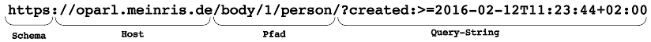

Aufbau einer URL

Den URLs (für *Uniform Resource Locators*) kommt eine besondere Bedeutung zu und es werden deshalb eine Reihe von Anforderungen an deren Aufbau und Eigenschaften gestellt. Die allgemeine Funktionsweise von URLs ist in RFC 3986 beschrieben[^3].

Grundsätzlich **müssen** alle Zugriffe zustandslos erfolgen können, also ohne Sessioninformationen wie Cookies. Das bedeutet, dass alle Informationen, die zum Abrufen eines Objekts nötig sind, in der URL vorhanden sein müssen.

### 2.3.1 URL-Kanonisierung

Um Objekte eindeutig identifizieren zu können ist es notwendig, dass ein Server für ein Objekt genau eine unveränderliche URL benutzt. Diese Festlegung auf genaue eine eindeutige URL wird Kanonisierung genannt. Ein Server **muss** deshalb für jedes seiner Objekte eine kanonische URL bestimmen können.

Es wird empfohlen keine IP-Adressen in URLs zu benutzen, sondern einen mit Bedacht gewählten Hostnamen einzusetzen. Das ist vor allem im Hinblick auf die Langlebigkeit der URLs wichtig.

Um die Kanonisierung zu gewährleisten **sollten** ridesharing.api-Server so konfiguriert werden, dass sie nur über eine bestimmte Domain erreichbar sind. ridesharing.api-Server **sollten** dagegen möglichst **nicht** nur über eine IP-Addresse sowie möglichst auch **nicht** über weitere, nicht kanonische URLs erreichbar sein.

Wenn ein Server auch durch eine nicht-kanonische URL erreichbar ist, dann **sollte** eine entsprechende HTTP-Anfrage mit einer Weiterleitung auf die entsprechende kanonische URL und HTTP-Status-Code 301 beantwortet werden. Zur Überprüfung kann z.B. der `Host`-Header einer HTTP-Anfrage verwendet werden.

Beim Pfad-Bestandteil der URL **müssen** Server-Implementierer darüber hinaus beachten, dass zur kanonischen Schreibweise auch die Groß- und Kleinschreibung, die Anzahl von Schrägstrichen als Pfad-Trennzeichen und die Anzahl von führenden Nullen vor numerischen URL-Bestandteilen gehört.

Die Kanonisierung umfasst auch den Query-String-Bestandteil der URL. Wie auch beim Pfad gilt, dass für jeden Parameter und jeden Wert im Query-String genau eine kanonische Schreibweise gelten **muss**.

Darüber hinaus **sollte** der Server-Implementierer darauf achten, Query-String-Parameter immer nach demselben Prinzip zu sortieren. Als Beispiel: Die beiden URLs

```
https://ridesharing.example.org/stops?person=1&trip=2
https://ridesharing.example.org/stops?trip=2&person=1
```

unterscheiden sich lediglich in der Reihenfolge der Query-String-Parameter. Da sie jedoch nicht identisch sind, könnten Clients annehmen, dass beide URLs verschiedene Objekte repräsentieren.

Clients **sollen** die vom Server gelieferten URLs bei Anzeige, Speicherung und Weiterverarbeitung nicht verändern.

### 2.3.2 HTTP und HTTPS

Der Einsatz des verschlüsselten HTTPS wird empfohlen. Bei Verwendung von HTTPS wird allen URLs "https://" voran gestellt, ansonsten beginnen URLs mit "http://".

Aus Gründen der URL-Kanonisierung ist es **zwingend** notwendig, dass ein Server-Betreiber sich entweder für HTTP oder für HTTPS entscheidet. Es jedoch möglich, eine Weiterleitung (HTTP Status-Code 301) einzurichten. Eine Weiterleitung von HTTPS auf HTTP wird **nicht empfohlen**.

### 2.3.3 Langlebigkeit

Weiterhin sollen URLs langlebig sein, sodass sie möglichst lange zur Abfrage des dazugehörigen Objekts verwendet werden können.

In URLs **sollten** deshalb nur Eigenschaften des Objekts aufgenommen werden, die nicht verändert werden. Ändert sich beispielsweise die Kennung einer Drucksache im Verlauf ihrer Existenz, dann scheidet sie für die Bildung der URL aus.

Des Weiteren sollen Eigenschaften der Implementierung nicht sichtbar sein. Ist ein ridesharing.api-Server beispielsweise in PHP geschrieben, **sollte** dies **nicht** dazu führen, dass im Pfad ein Bestandteil wie "ridesharing.php/" erscheint.

Weitere Empfehlungen für langlebige URLs liefern Tim Berners-Lee[^4] sowie die Europäische Kommission[^5].

## 2.4 JSON-Ausgabe

Ein ridesharing.api-Server **muss** Objekte in Form von JSON ausgeben. Die Abkürzung JSON steht für "JavaScript Object Notation". Das JSON-Format ist in RFC 7159[^6] beschrieben.

Sämtliche JSON-Ausgabe **muss** in UTF-8 ohne Byte Order Mark (BOM) geschehen. Dies entspricht RFC 7159 Section 8.1[^7]. Gemäß RFC 7159 Section 7[^8] **darf** UTF-8 String-Escaping verwendet werden. XML-/HTML-String-Escaping **darf nicht** verwendet werden.

Eine Syntaxübersicht und weitere Implementierungshinweise finden sich auf [json.org](http://json.org/).

Es ist gestattet, weitere zur JSON-Ausgabe semantisch identische Formate[^9] anzubieten. Da diese jedoch nicht Bestandteil der Spezifikation sind, **sollten** sich Clients nicht auf deren Vorhandensein verlassen.

### 2.4.1 In der ridesharing.api verwendete Datentypen

In ridesharing.api werden alle in JSON definierten Dateitypen verwendet:

**object:**

Objects entsprechen der Definition des Objects in RFC 7159 Section 4

**array:**

Arrays entsprechen der Definition des Arrays in RFC 7159 Section 5

**integer:**

Integers entsprechen der Definition des Integer-Parts der Number aus RFC 7159 Section 6

**boolean:**

Booleans entsprechen der Definition von Boolean in RFC 7159 Section 3

**string:**

Strings entsprechen der Definition der Unicode-Strings aus RFC 7159 Section 7

In der ridesharing.api werden verschiedene String-Typen verwendet. Wenn von diesen Typen gesprochen wird, so wird automatisch ein JSON-String vorausgesetzt:

**url:**

Eine URL ist ein String, der entsprechend des URL-Kapitels formatiert wurde.

**url (Object):**

Eine URL mit in Klammern angehängtem Objektname beschreibt eine URL auf eben diesen Objekttypus.

**date:**

Entspricht einem Datum ohne Uhrzeit und ohne Zeitzone, wie sie im folgenden Abschnitt beschrieben werden.

**date-time:**

Entspricht einem Datum und einer Uhrzeit mit Zeitzone, wie sie im folgenden Abschnitt beschrieben werden.

### 2.4.2 Datums- und Zeitangaben

Für Datums- und Zeitangaben wird eine Spezialisierung der in ISO 8601 beschriebenen Formate verwendet. Ein Datum (date) **muss** muss die Form `yyyy-mm-dd` besitzen und ein Zeitpunkt (date-time) **muss** in der Form `yyyy-mm-ddThh:mm:ss±hh:mm` angegeben werden.

Beispiel für ein Datum: `1969-07-21`

Beispiel für einen Zeitpunkt: `1969-07-21T02:56:00+00:00`

### 2.4.3 `null`-Werte und leere Listen

JSON erlaubt es grundsätzlich, Eigenschaften mit dem Wert `null` zu versehen. Eigenschaften **sollten** nicht mit dem Wert `null` ausgegeben werden, wenn zu einer Eigenschaft keine Daten vorliegen. Obligatorische Eigenschaften **dürfen nicht** den Wert `null` haben.

Im Fall von Arrays erlaubt JSON grundsätzlich die Ausgabe von `[]` für leere Arrays. Wie bei `null` wird auch hier **empfohlen**, auf die Ausgabe einer Eigenschaft mit dem Wert `[]` zu verzichten, wenn zu einer Eigenschaft keine Daten vorliegen. Bei obligatorischen Eigenschaften **muss** jedoch eine leere Liste ausgegeben werden.

Bei nicht obligatorischen Eigenschaften sollte gleichermaßen auf die Ausgabe eines leeren Strings `""` verzichtet werden.

## 2.5 Objektlisten und Paginierung

Oft wird für ein Attribut kein Wert ausgegeben, sondern ein anderes Objekt oder eine Liste von Objekten. Dabei kann eine Referenz auf das Objekt bzw. die Objektliste angegeben werden, oder das Objekt bzw. die Objektlist wird intern ausgegeben. Beide Verfahren sollen im Folgenden erklärt werden. Zu beachten ist, dass für jedes Listenattribut festgelegt ist, welches dieser Verfahren jeweils zu verwenden ist. Diese Information ist den Schemadefinitionen zu entnehmen.

### 2.5.1 Referenzierung von Objekten via URL

Bei der Referenzierung einzelner Objekte wird eine URL angegeben, welche auf das entsprechende Objekt verweist. Der Typ ist hierbei ein `string (url: Objekt-ID)`. Ein Beispiel hierfür ist `location` in `Stop`:

```json
{
    "id": "https://ridesharing-api.example-ridesharing.de/stop/1"
    "type": "https://schema.ridesharing-api.org/1.0/Stop",
    "location": "https://ridesharing-api.example-ridesharing.de/location/1",
    [...]
}
```

Es kann auch eine Liste von Referenzen ausgegeben werden. Der Typ ist in diesem Fall `array of string (url: Objekt-ID)`.

Ein Beispiel hierfür ist `stop` in `Trip`:

```json
{
    "id": "https://ridesharing-api.example-ridesharing.de/trip/1"
    "type": "https://schema.ridesharing-api.org/1.0/Trip",
    "stop": [
        "https://ridesharing-api.example-ridesharing.de/stop/1",
        "https://ridesharing-api.example-ridesharing.de/stop/2",
        [...],
    ],
    [...]
}
```

### 2.5.2 Interne Ausgabe von Objekten

Objekte können auch intern ausgegeben werden. Dabei wird das gesamte Objekt als Wert eines Attributs angegeben. Ein Beispiel für ein internes Objekt ist `location` in `ridesharing-api:Stop`:

```json
{
    "id": "https://ridesharing-api.example-ridesharing.de/stop/1"
    "type": "https://schema.ridesharing-api.org/1.0/Stop",
    "location": {
        "id": "https://ridesharing-api.example-ridesharing.de/location/1"
        "type": "https://schema.ridesharing-api.org/1.0/Location",
        [...]
    },
    [...]
}
```

Ebenso kann eine Liste von Objekten intern ausgegeben werden. Hier das Beispiel des Attributes `stop` in `ridesharing-api:Trip`.

```json
{
    "id": "https://ridesharing-api.example-ridesharing.de/trip/1"
    "type": "https://schema.ridesharing-api.org/1.0/Trip",
    "stop": [
        {
            "id": "https://ridesharing-api.example-ridesharing.de/stop/1"
            "type": "https://schema.ridesharing-api.org/1.0/Stop",
        },
        {
            "id": "https://ridesharing-api.example-ridesharing.de/stop/2"
            "type": "https://schema.ridesharing-api.org/1.0/Stop",
        },
        [...]
    ]
}
```

Bei der internen Ausgabe von Objekten **darf** der Server keine gelöschten Objekte ausgeben.

### 2.5.3 Externe Objektlisten

Es können auch Referenzen zu sogenannten externen Objektlisten angegeben werden. Die externe Liste enthält dann die betreffenden Objekte in Form einer Listenausgabe. Ein Beispiel dafür ist `route` in `ridesharing-api:System`.

`ridesharing-api:System`:

```json
{
    "id": "https://ridesharing-api.example-ridesharing.de/system"
    "type": "https://schema.ridesharing-api.org/1.0/System",
    "route": "https://ridesharing-api.example-ridesharing.de/routes"
}
```

Die externe Objektliste:

```json
{
    "data": [
        {
            "id":"https://ridesharing-api.example-ridesharing.de/route/1",
            "type": "https://schema.ridesharing-api.org/1.0/System",
            [...]
        },
        {
            "id":"https://ridesharing-api.example-ridesharing.de/route/2",
            "type": "https://schema.ridesharing-api.org/1.0/System",
            [...]
        },
        [...]
    ],
    ...
}
```

### 2.5.4 Paginierung

Für externe Objektlisten ist eine Aufteilung sogenannte *Listenseiten* vorgesehen, wobei jede Listenseite eine eigene URL erhält. Das dient dazu, die bei der jeweiligen Anfrage übertragenen Datenmengen und Antwortzeiten zu begrenzen.

Die Entscheidung, ob eine externe Objektliste mit Paginierung ausgegeben wird, liegt allein beim Server. Bei Listen mit mehr als 100 Einträgen wird dies **empfohlen**.

Ein Server **muss** für eine stabile Sortierung von Listeneinträgen sorgen. Das heißt, dass die Sortierung der Einträge einem konstanten Prinzip folgt und sich nicht von Abfrage zu Abfrage ändert. Das kann z.B. durch die Sortierung von Objekten nach einer eindeutigen und unveränderlichen ID erreicht werden.

Jede Listenseite **muss** die Attribute folgenden Attribute enthalten:

- **data** (Array der intern ausgegebenen Objekte)
- **pagination** (Object)
- **links** (Object)

Für `pagination` sind die folgenden Attribute festgelegt, die alle **optional** sind:

- `totalElements`: Gibt die Gesamtanzahl der Objekte in der Liste an. Diese Zahl kann sich unter Umständen bis zum Aufruf der nächsten Listenseiten ändern.
- `elementsPerPage`: Gibt die Anzahl der Objekte pro Listenseite an. Dieser Wert muss auf allen Listenseiten bis auf die letzte gleich sein.
- `currentPage`: Gibt die aktuelle Seitenzahl in der Liste an.
- `totalPages`: Gibt die Gesamtanzahl der Seiten in der Liste an.

Für `links` sind folgende Attribute festgelegt, die bis auf `next` alle **optional** sind:

- `first`: URL der ersten Listenseite
- `prev`: URL der vorherigen Listenseite
- `self`: Die kanonische URL dieser Listenseite
- `next`: URL der nächsten Listen. Für alle Seiten bis auf die letzte ist die Angabe dieser URL **zwingend**.
- `last`: URL der letzten Listenseite

```json
{
    "data": [
        {...},
        {...},
        ...
    ],
    "pagination": {
        "totalElements": 50000,
        "elementsPerPage": 100,
        "currentPage": 3,
        "totalPages":500
    },
    "links": {
        "first": "https://ridesharing.example.org/trips/",
        "prev": "https://ridesharing.example.org/trips/?page=2",
        "self": "https://ridesharing.example.org/trips/?page=3",
        "next": "https://ridesharing.example.org/trips/?page=4",
        "last": "https://ridesharing.example.org/trips/?page=500",
    }
}
```

### 2.5.5 Filter

Externe Objektlisten können mit den URL-Parametern `created_since`, `created_until`, `modified_since` und `modified_until` eingeschränkt werden. Diese Parameter beziehen sich auf die entsprechenden Attribute der jeweiligen Objekte, wobei reservierte Zeichen URL-Kodiert werden müssen. Ein Server muss diese Parameter bei allen externen Objektlisten unterstützen.

Die Filter werden vom Client benutzt, indem die gewünschten URL-Parameter an die URL der ersten Listenseite angehängt werden. Bei allen weiteren Seiten, genauer gesagt bei den Werten von `links`, **muss** der Server sicherzustellen, dass die verwendeten Filter erhalten bleiben.

Ein Server **muss** für den im nächsten Abschnitt beschrieben Aktualisierungsmechanismus auch die den Filtern entsprechenden gelöschten Objekte ausgeben, wenn der Parameter `modified_since` gesetzt ist. Wenn `modified_since` nicht gesetzt ist, dann **dürfen** die gelöschten Objekte **nicht** ausgegeben werden. Dadurch kann sich ein Client effizient darüber informieren, welche der Objekte in seinem lokalen Bestand gelöscht wurden.

Lautet die URL für eine Liste von Drucksachen wie folgt:

```
https://ridesharing.example.org/trips/
```

kann der Client die folgende URL bilden, um die Ausgabe der Liste auf Drucksachen einzuschränken, die seit dem 1. Januar 2014 veröffentlicht wurden:

```
https://ridesharing.example.org/trips/?created_since=2014-01-01T00%3A00%3A00%2B01%3A00
```

Mehrere Parameter können auch gemeinsam verwendet werden. So kann man z.B. eine Einschränkung vom 1.1.2014 bis zum 31.1.2014 vornehmen:

```
https://ridesharing.example.org/trips/?created_since=2014-01-01T00%3A00%3A00%2B01%3A00&created_until=2014-01-31T23%3A59%3A59%2B01%3A00
```

Die genannten URL-Parameter erwarten grundsätzlich eine vollständige `date-time`-Angabe.

Des Weiteren kann ein Client die Anzahl der Objekte pro Listenseite durch den URL-Parameter `limit` begrenzen, der sich auf das gleichnamige Attribut bezieht. Ein Client **darf nicht** erwarten, dass sich ein Server an seine `limit`-Anfrage hält.

### 2.5.6 Der Aktualisierungsmechanismus

Der Hauptnutzen der Filter ist die Möglichkeit, einen lokalen Datenbestand inkrementell zu aktualisieren.

Ein Client könnte z.B. am 1.1.2014 um 2:00 Uhr deutscher Zeit die Liste aller Drucksachen herunterladen und in einer Datenbank speichern.

```
https://ridesharing.example.org/trips/
```

Um den Datenbestand am nächsten Tag zu aktualisieren, ruft der Client dieselbe URL auf, diesmal jedoch mit dem Parameter `modified_since` mit dem Wert `2014-01-01T02:00:00+01:00`.

```
https://ridesharing.example.org/trips/?modified_since=2014-01-01T02%3A00%3A00%2B01%3A00
```

Diese Liste ist in der Regel deutlich kürzer als die Liste aller Objekte, sodass die Aktualisierung bedeutend schneller ist als der erste Abruf. Der Client muss außerdem nur noch eine deutlich kleinere Menge an Objekten in die Datenbank einfügen, aktualisieren oder löschen, um den gleichen Datenstand wie der Server zu haben.

## 2.6 Cross-Origin Resource Sharing (CORS)

Wenn Webbrowser mittels Skript auf JSON-Ressourcen zugreifen sollen unterliegen diese Zugriffe üblicherweise einer *Same-Origin-Policy* (SOP). Das heißt, eine Anfrage ist nur an den Server zulässig, der auch das initiierende Skript ausgeliefert hat. Anfragen an andere Server werden vom Browser blockiert. Diese Einschränkung dient im Allgemeinen der Sicherheit von Webbrowsern.[^10]

Um die Daten von ridesharing.api-Servern auch im Kontext von Webanwendungen flexibel nutzen zu können, ist die Überwindung der SOP nötig. Hierzu dient *Cross-Origin Resource Sharing* (CORS)[^11]. Mittels CORS kann ein Server mitteilen, dass bestimmte von ihm ausgelieferte Ressourcen auch innerhalb von Webapplikationen genutzt werden dürfen, die nicht vom selben Server ausgeliefert werden. Technisch wird dies durch Ausgabe zusätzlicher HTTP-Header erreicht.

ridesharing.api-Server **müssen** für jegliche Anfrage, die mit der Ausgabe von JSON-Daten beantwortet wird (das sind alle Anfragen außer Dateizugriffe) den folgenden HTTP-Antwort-Header senden:

```
Access-Control-Allow-Origin: *
```

Der HTTP-Antwort-Header `Access-Control-Allow-Methods` **sollte** darüber hinaus **nicht** gesetzt sein, oder **muss** die Methode `GET` beinhalten.

Entwicklerinnen von Webanwendungen sollten sich darüber bewusst sein, dass durch die direkte Einbindung von Skripten Dritter in ihre Anwendungen mögliche Sicherheitsrisiken entstehen. Für den Fall, dass ein ridesharing.api-Server, etwa in Folge einer Manipulation, Schadcode ausliefert, könnte dieser unmittelbar von Skripten im Browser ausgeführt werden.

## 2.7 Gelöschte Objekte

In der ridesharing.api **dürfen** Objekte **nicht** einfach gelöscht werden, sodass unter der betreffenden URL kein gültiges Objekt ausgeliefert wird. Stattdessen wird ein sogenanntes *soft delete* verwendet.

Dies wird durch die folgenden Regeln gewährleistet.

Wenn ein Objekt gelöscht wird,

- **muss** das Objekt das zusätzliche Attribut `deleted` mit dem Wert `true` bekommen
- **muss** das Attribut `modified` auf den Zeitpunkt der Löschung setzen
- **müssen** die Attribute `id`, `type` und `created` erhalten bleiben
- **dürfen** alle weiteren Attribute entfernt werden

Als HTTP-Statuscode **muss** weiterhin 200 verwendet werden.

## 2.8 Ausnahmebehandlung

Wenn ein Server eine Anfrage nicht bearbeiten kann, z.B. weil die URL ungültig ist oder das angefragte Objekt nicht existiert, dann **sollte** er mit dem entsprechenden HTTP-Statuscode antworten.

Ein Server **sollte** in diesem Fall ein Objekt ausgeben, das die folgenden 3 Attribute enthält:

- `type`: Enthält als Wert die URL `https://ridesharing-api.org/1.0/Error`
- `message`: Eine Fehlermeldung, die zur Anzeige für einen Nutzer gedacht ist. Die Fehlermeldung sollte deshalb in der Sprache der durch die Schnittstelle ausgelieferten Inhalte verfasst sein
- `debug`: Zusätzliche Informationen über den Fehler

Wenn ein Server ein solches Objekt ausgibt, dann **muss** er dazu einen HTTP-Statuscode senden, der einen Fehler anzeigt.

Ein Client **darf nicht** voraussetzen, dass er im Fall eines Fehlers verwertbare Informationen wie das oben beschriebene Fehlerobjekt erhält.

## 2.9 ridesharing.api Endpunkt

Als ridesharing.api Endpunkt bzw. Einsprungspunkt zur Schnittstelle wird ein `ridesharing.api:System` Objekt genutzt. Falls auf einem HTTP-Host mehrere ridesharing.api-Schnittstellen oder mehrere ridesharing.api Versionen parallel installiert sind, **müssen** diese eindeutige und voneinander unabhängige ridesharing.api-Endpunkte anbieten. Es ist allerdings möglich, eine Liste von `ridesharing.api:System`-Objekten auszugeben, die z.B. auf verschiedene ridesharing.api-Versionen einer Schnittstelle verweisen.

## 2.10 Instanzierung

Ein wichtiger Aspekt im Datenstandard ist die Instanzierung. Damit ist gemeint, dass auch Mitfahrbörsen ganz analog zum ÖPNV einen Soll- und einen Ist-Fahrtplan haben.

Die allermeisten Börsen haben zur Zeit nur einen Soll-Fahrplan, den Börsen ist meistens nicht bekannt, ob eine konkrete Fahrt wirklich stattfindet. Dafür hat ein relevanter Teil der Mitfahrangebote eine Art Fahrtplan: die Fahrten finden nicht nur ein mal statt, sondern regelmäßig. Im Falle einer regionalen Fahrt ist dies zum Beispiel eine tägliche Fahrt zur Arbeit, im Falle einer überregionalen Fahrt Wochenend-Pendler, die jedes Wochenende an einen anderen Ort fahren.

Die ridesharing.api bildet die Instanzierung über die Single*-Objekte ab. `Trip`, `Stop` und `Location` repräsentieren den Soll-Fahrplan und haben daher keine Festlegung auf ein Datum, sondern nur auf eine Zeit und einen Rythmus. `SingleTrip`, `SingleStop` und `SingleLocation` dagegen repräsentieren konkrete Fahrten und haben daher ein exaktes Datum sowie exakte Uhrzeiten.

Durch die Verlinkung via `id`s können Update der instanzierten Datensätze auch einzeln vorgenommen werden, so dass die Serverlast gering gehalten werden kann.

# 3 Schema

Dieses Kapitel beschreibt das Schema der ridesharing.api. Das Schema definiert die Objekttypen und ihre Eigenschaften. Darüber hinaus ist im Schema auch festgelegt, in welcher Beziehung verschiedene Objekttypen zu einander stehen.

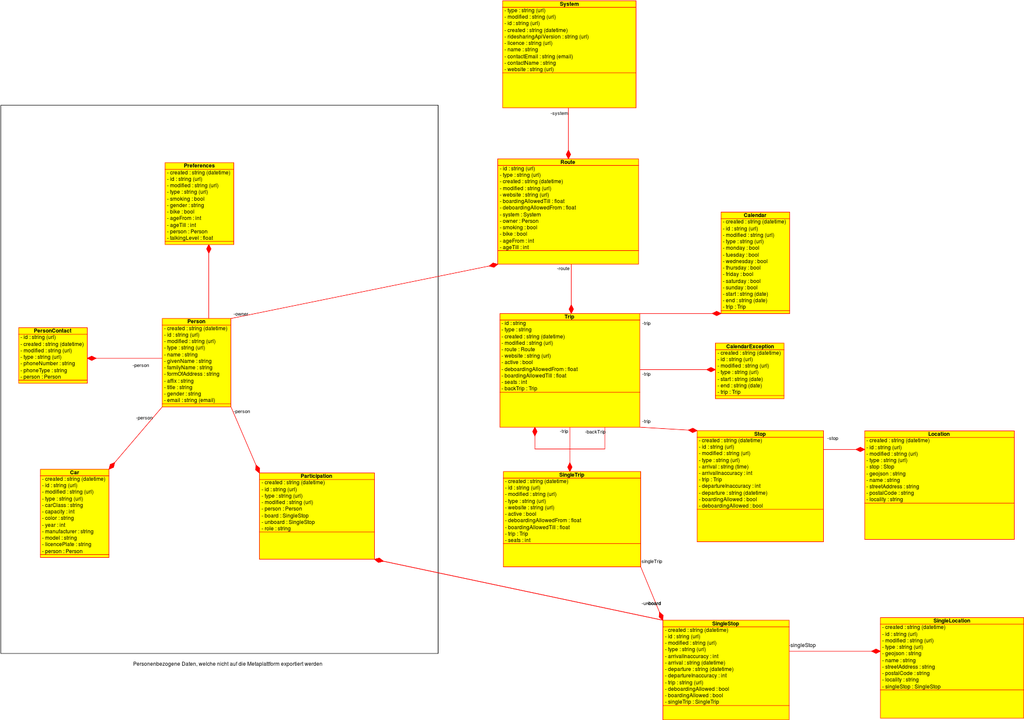

## 3.1 Die Objekte

Die ridesharing.api nutzt folgenden Objekte:

- ridesharing.api:System
- ridesharing.api:Route
- ridesharing.api:Trip
- ridesharing.api:Calendar
- ridesharing.api:CalendarException
- ridesharing.api:Stop
- ridesharing.api:Location
- ridesharing.api:SingleTrip
- ridesharing.api:SingleStop
- ridesharing.api:SingleLocation
- ridesharing.api:Person
- ridesharing.api:PersonContact
- ridesharing.api:Participation
- ridesharing.api:Preferences
- ridesharing.api:Car

Grundsätzlich muss jedes Objekt unter seiner ID abrufbar sein - auch dann, wenn das Objekt in anderen Objekten intern ausgegeben wird. Bei der internen Ausgabe wird beim internen Objekt auf die Rückreferenz auf das Elternobjekt verzichtet.

Als Beispiel hier eine Ausgabe von `ridesharing-api:Trip`, in welchem ein `ridesharing-api:Stop` enthalten ist:

```json
{
    "id": "https://api.meine-mitfahrboerse.de/trip/123",
    "type": "https://schema.ridesharing-api.org/1.0/Trip",
    "created": "2019-02-07T18:28:18",
    "modified": "2019-03-14T15:09:26",
    "active": true,
    "seats": 3,
    "website": "https://meine-mitfahrboerse.de/trip/123",
    "route": "https://api.meine-mitfahrboerse.de/route/456",
    "stop": [
        {
            "id": "https://api.meine-mitfahrboerse.de/stop/789",
            "type": "https://schema.ridesharing-api.org/1.0/Stop",
            "created": "2019-02-07T18:28:18",
            "modified": "2019-03-14T15:09:26",
            "arrival": "10:00:00",
            "departure": "10:10:00",
            "location": {
                "id": "https://api.meine-mitfahrboerse.de/stop/012",
                "type": "https://schema.ridesharing-api.org/1.0/Location",
                "name": "Lyonesse Bahnhof"
            }
        },
        {
            "id": "https://api.meine-mitfahrboerse.de/stop/345",
            "type": "https://schema.ridesharing-api.org/1.0/Stop",
            "created": "2019-02-07T18:28:18",
            "modified": "2019-03-14T15:09:26",
            "arrival": "12:00:00",
            "departure": "12:10:00",
            "location": {
                "id": "https://api.meine-mitfahrboerse.de/stop/678",
                "type": "https://schema.ridesharing-api.org/1.0/Location",
                "name": "Atlantis Hafen"
            }
        },
        [...]
    ]
}
```

Das enthaltene `ridesharing-api:Stop` muss auch einzeln abgerufen werden können. Dabei kommt dann das Eltern-Objekt als zusätzliches Attribut hinzu.:

```json
{
    "id": "https://api.meine-mitfahrboerse.de/stop/789",
    "type": "https://schema.ridesharing-api.org/1.0/Stop",
    "created": "2019-02-07T18:28:18",
    "modified": "2019-03-14T15:09:26",
    "arrival": "10:00:00",
    "departure": "10:10:00",
    "trip": "https://api.meine-mitfahrboerse.de/trip/123",
    "location": {
        "id": "https://api.meine-mitfahrboerse.de/stop/012",
        "type": "https://schema.ridesharing-api.org/1.0/Location",
        "name": "Lyonesse Bahnhof"
    }
}
```

Die im ersten Beispiel gezeigte Liste kann auch als Liste an URLs geschrieben werden:

```json
{
    "id": "https://api.meine-mitfahrboerse.de/trip/123",
    "type": "https://schema.ridesharing-api.org/1.0/Trip",
    "created": "2019-02-07T18:28:18",
    "modified": "2019-03-14T15:09:26",
    "active": true,
    "seats": 3,
    "website": "https://meine-mitfahrboerse.de/trip/123",
    "route": "https://api.meine-mitfahrboerse.de/route/456",
    "stop": [
        "https://api.meine-mitfahrboerse.de/stop/789",
        "https://api.meine-mitfahrboerse.de/stop/345",
        [...]
    ]
}
```

## 3.2 Übergreifende Aspekte

### 3.2.1 Vollständigkeit

Alle regulär öffentlich abrufbaren Informationen **sollten** auch in der ridesharing.api ausgegeben werden, solange dies nicht den Datenschutzbestimmungen widerspricht. Daher sind sämtliche Felder im Schema als **empfohlen** zu behandeln, wenn nicht explizit etwas anderes angegeben wurde.

### 3.2.2 Herstellerspezifische Erweiterungen

In der ridesharing.api können zusätzliche, herstellerspezifische Eigenschaften hinzugefügt werden. Dazu wird diesen Eigenschaften ein Herstellerprefix vorangestellt. So könnte man z.B. `ridesharing-api:Location` um einen Point of Interest erweitern:

```
"BeispielHersteller:pointOfInterest": "Altes Stadttor",
```

### 3.2.3 URL-Pfade in den Beispielen

ridesharing.api-Clients wissen nichts vom Aufbau von Pfaden innerhalb von URLs, müssen dies nicht wissen, und es gibt deshalb in der ridesharing.api-Spezifikation keine Festlegungen dazu. Die in den Beispielen verwendeten URLs zeigen einen möglichen Weg zur Umsetzungen der Empfehlungen in URLs.

## 3.3 Eigenschaften mit Verwendung in mehreren Objekttypen

### 3.3.1 `id`

Die Eigenschaft `id` enthält den eindeutigen Bezeichner des Objekts, nämlich seine URL. Dies ist ein **zwingendes** Merkmal für jedes Objekt.

### 3.3.2 `type`

Objekttypenangabe des Objekts, **zwingend** für jedes Objekt. Der Wert ist eine Namespace-URL. Für die ridesharing.api-Objekttypen sind die folgenden URLs definiert:

| Typ (kurz) | Namespace-URL |
| --- | --- |
| `ridesharing-api:Calendar` | https://schema.ridesharing-api.org/1.0/Calendar |
| `ridesharing-api:CalendarException` | https://schema.ridesharing-api.org/1.0/CalendarException |
| `ridesharing-api:Car` | https://schema.ridesharing-api.org/1.0/Car |
| `ridesharing-api:Location` | https://schema.ridesharing-api.org/1.0/Location |
| `ridesharing-api:Participation` | https://schema.ridesharing-api.org/1.0/Participation |
| `ridesharing-api:Person` | https://schema.ridesharing-api.org/1.0/Person |
| `ridesharing-api:PersonContact` | https://schema.ridesharing-api.org/1.0/PersonContact |
| `ridesharing-api:Preferences` | https://schema.ridesharing-api.org/1.0/Preferences |
| `ridesharing-api:Route` | https://schema.ridesharing-api.org/1.0/Route |
| `ridesharing-api:SingleLocation` | https://schema.ridesharing-api.org/1.0/SingleLocation |
| `ridesharing-api:SingleStop` | https://schema.ridesharing-api.org/1.0/SingleStop |
| `ridesharing-api:SingleTrip` | https://schema.ridesharing-api.org/1.0/SingleTrip |
| `ridesharing-api:Stop` | https://schema.ridesharing-api.org/1.0/Stop |
| `ridesharing-api:System` | https://schema.ridesharing-api.org/1.0/System |
| `ridesharing-api:Trip` | https://schema.ridesharing-api.org/1.0/Trip |

### 3.3.3 `created`

Datum und Uhrzeit der Erstellung des jeweiligen Objekts.

Diese Eigenschaft **muss** in allen Objekttypen angegeben werden.

### 3.3.4 `modified`

Diese Eigenschaft kennzeichnet stets Datum und Uhrzeit der letzten Änderung des jeweiligen Objekts.

Diese Eigenschaft **muss** - genau wie `created` - in allen Objekttypen angegeben werden.

Es ist **zwingend**, dass bei jeder Änderung eines Objekts der Wert dieses Attributs auf die zu diesem Zeitpunkt aktuelle Uhrzeit gesetzt wird, da ein Client in der Regel seinen Datenbestand nur auf Basis dieses Attributs verlustfrei aktualisieren kann.

## 3.4 System

Ein ridesharing-api:System-Objekt repräsentiert eine ridesharing.api-Schnittstelle für eine bestimmte ridesharing.api-Version. Es ist außerdem der Startpunkt für Clients beim Zugriff auf einen Server.

| Name | Typ | Beschreibung |
| --- | --- | --- |
| `id` | url |  |
| `type` | string |  |
| `created` | date-time | **ZWINGEND** Zeitpunkt der Erstellung. |
| `modified` | date-time | **ZWINGEND** Zeitpunkt der letzten Änderung. |
| `ridesharingApiVersion` | string | **ZWINGEND** ridesharing.api Version |
| `otherRidesharingApiVersions` | array of url (System) | Andere ridesharing.api Versionen |
| `route` | array of url (Route) | Die zu dem System gehörenden Routen. es wird auf eine paginierte externe Objektliste verlinkt. |
| `license` | url | Lizenz, unter der durch diese API abrufbaren Daten stehen. |
| `name` | string | Nutzerfreundlicher Name für das System, mit dessen Hilfe Nutzerinnen und Nutzer das System erkennen und von anderen unterscheiden können. |
| `contactName` | string | Name der Ansprechpartnerin bzw. des Ansprechpartners oder der Abteilung, die über die in contactEmail angegebene Adresse erreicht werden kann. |
| `contactEmail` | string | E-Mail-Adresse für Anfragen zur ridesharing.api-API. Die Angabe einer E-Mail-Adresse dient sowohl NutzerInnen wie auch Entwicklerinnen von Clients zur Kontaktaufnahme mit dem Betreiber. |
| `website` | url | URL der Website des Mitfahr-Portals |

## 3.5 Route

Eine Route, zu der eine oder mehrere Fahrten gehören.

| Name | Typ | Beschreibung |
| --- | --- | --- |
| `id` | url |  |
| `type` | string |  |
| `created` | date-time | Zeitpunkt der Erstellung. |
| `modified` | date-time | Zeitpunkt der letzten Änderung. |
| `system` | url (System) | System |
| `owner` | url (Person) | Besitzer der Fahrt. Wert darf nur bei personenbesogenen Exporten ausgegeben werden. |
| `trip` | array of url (Trip) | Die zu der Route gehörenden Fahrten. |
| `active` | boolean | Zeigt an, ob die Fahrt aktuell aktiv ist. |
| `published` | date-time | Zeitpunkt der Veröffentlichung. |
| `expired` | date-time | Zeitpunkt, ab welchem das Angebot nicht mehr gültig ist. |
| `boardingMinimum` | float | Mindestanteil der Fahrt, die ein Mitfahrender dabei sein muss. |
| `boardingAllowedTill` | float | Anteil der Fahrt, ab dem kein Zusteigen mehr erlaubt ist. |
| `deboardingAllowedFrom` | float | Anteil der Fahrt, bis zu dem Aussteigen nicht erlaubt ist. |
| `maxDetourTime` | integer | Maximale Anzahl an Minuten, die der / die FahrerIn zum Einsammeln der Mitfarherer zusätzlich fahren würde. |
| `maxDetourDistance` | integer | Maximale Anzahl an Kilometern, die der / die FahrerIn zum Einsammeln der MitfahrererInnen zusätzlich fahren würde. |
| `seats` | integer | Anzahl der Sitze |
| `nonsmoking` | boolean | Nichtraucher-Fahrt. |
| `bike` | integer | Anzahl an Fahrrädern, welche mitgenommen werden können. |
| `ageFrom` | integer | Mindestalter der MitfahrerInnen, numerischer Wert. |
| `ageTill` | integer | Maximales Alter der MitfahrerInnen, numerischer Wert. |
| `gender` | string | Geschlecht der MitfahrerInnen |
| `talkingLevel` | float | Das Level an Gesprächigkeit. |
| `website` | url | URL der Route auf dem Mitfahr-Portals (Deeplink) |

## 3.6 Trip

Das Objekt beschreibt eine abstrakte Fahrt, welche sich wöchentlich wiederholen kann.

| Name | Typ | Beschreibung |
| --- | --- | --- |
| `id` | url |  |
| `type` | string |  |
| `created` | date-time | Zeitpunkt der Erstellung. |
| `modified` | date-time | Zeitpunkt der letzten Änderung. |
| `route` | url (Route) | Abstrakte Route, mit der eine oder mehrere Fahrten zusammengefasst werden. |
| `car` | url (Car) | Fahrzeug |
| `backTrip` | url (Trip) | Der in die exakt entgegengesetzte Richtung laufende Trip, also die Rückfahrt. |
| `relatedTrip` | array of url (Trip) | Trips, welche in irgendeiner anderen Form mit dem bestehenden Trip in Zusammenhang stehen (z.B. Weiterfahrten). |
| `stop` | array of url (Stop) | Haltepunkte |
| `singleTrip` | array of url (SingleTrip) | Die Instanzierungen des abstrakten Trips. |
| `active` | boolean | Zeigt an, ob die Fahrt aktuell aktiv ist. |
| `published` | date-time | Zeitpunkt der Veröffentlichung. |
| `expired` | date-time | Zeitpunkt, ab welchem das Angebot nicht mehr gültig ist. |
| `maxDetourTime` | integer | Maximale Anzahl an Minuten, die der / die FahrerIn zum Einsammeln der Mitfahrerer zusätzlich fahren würde. Wird nur ausgegeben, wenn der Wert sich vom Wert in Route unterscheidet. |
| `maxDetourDistance` | integer | Maximale Anzahl an Kilometern, die der / die FahrerIn zum Einsammeln der MitfahrererInnen zusätzlich fahren würde. Wird nur ausgegeben, wenn der Wert sich vom Wert in Route unterscheidet. |
| `seats` | integer | Anzahl der für Mitfahrer verfügbaren Sitze. Wird nur ausgegeben, wenn der Wert sich vom Wert in Route unterscheidet. |
| `boardingMinimum` | float | Mindestanteil der Fahrt, die ein Mitfahrender dabei sein muss. Wird nur ausgegeben, wenn der Wert sich vom Wert in Route unterscheidet. |
| `boardingAllowedFrom` | float | Anteil der Fahrt, bis zu dem Aussteigen nicht erlaubt ist. Wird nur ausgegeben, wenn der Wert sich vom Wert in Route unterscheidet. |
| `boardingAllowedTill` | float | Anteil der Fahrt, ab dem kein Zusteigen mehr erlaubt ist. Wird nur ausgegeben, wenn der Wert sich vom Wert in Route unterscheidet. |
| `nonsmoking` | boolean | Nichtraucher-Fahrt. Wird nur ausgegeben, wenn der Wert sich vom Wert in Route unterscheidet. |
| `bike` | integer | Anzahl an Fahrrädern, welche mitgenommen werden können. Wird nur ausgegeben, wenn der Wert sich vom Wert in Route unterscheidet. |
| `ageFrom` | integer | Mindestalter der MitfahrerInnen, numerischer Wert. Wird nur ausgegeben, wenn der Wert sich vom Wert in Route unterscheidet. |
| `ageTill` | integer | Maximales Alter der MitfahrerInnen, numerischer Wert. Wird nur ausgegeben, wenn der Wert sich vom Wert in Route unterscheidet. |
| `gender` | string | Geschlecht der MitfahrerInnen. Wird nur ausgegeben, wenn der Wert sich vom Wert in Route unterscheidet. |
| `website` | url | Öffentlicher Link auf das Angebot (Deeplink). |

## 3.7 Calendar

Das Objekt beschreibt eine Art Fahrplan, an denen die Mitfahrgelegenheit fährt.

| Name | Typ | Beschreibung |
| --- | --- | --- |
| `id` | url |  |
| `type` | string |  |
| `created` | date-time | Zeitpunkt der Erstellung. |
| `modified` | date-time | Zeitpunkt der letzten Änderung. |
| `trip` | url (Trip) | Fahrt |
| `calendarException` | array of url (CalendarException) | Ausnahmen zu den definierten Tagen |
| `start` | date | Beginn der Gültigkeit der angegebenen Wochentage |
| `end` | date | Ende der Gültigkeit der angegebenen Wochentage |
| `weekday` | array of integer | Tage, an denen die Fahrt angeboten wird, als Liste an ISO 8601 Wochentag-Nummern. |

## 3.8 CalendarException

Das Objekt beschreibt Ausnahmen zu den im Calendar beschriebenen Tagen.

| Name | Typ | Beschreibung |
| --- | --- | --- |
| `id` | url |  |
| `type` | string |  |
| `created` | date-time | Zeitpunkt der Erstellung. |
| `modified` | date-time | Zeitpunkt der letzten Änderung. |
| `calendar` | url (Calendar) | Calendar |
| `date` | date | Ausnahme-Datum zum bestehenden Calendar |
| `reason` | string | Grund für die Ausnahme |

## 3.9 Stop

Das Objekt beschreibt einen geplanten, noch nicht instanzierten Haltepunkte einer Fahrt.

| Name | Typ | Beschreibung |
| --- | --- | --- |
| `id` | url |  |
| `type` | string |  |
| `created` | date-time | Zeitpunkt der Erstellung. |
| `modified` | date-time | Zeitpunkt der letzten Änderung. |
| `trip` | url (Trip) | Mitfahrgelegenheit, zu welchem der Stop gehört. |
| `location` | url (Location) | Ort. |
| `singleStop` | array of url (Stop) | Instanzierter Stop |
| `arrival` | date-time | Geplante Ankunftszeit am Stop. |
| `arrivalInaccuracy` | integer | Geplante Ungenauigkeit der Ankunft in Sekunden |
| `departure` | date-time | Geplante Abfahrtzeit am Stop. |
| `departureInaccuracy` | integer | Geplante Ungenauigkeit der Abfahrt in Sekunden |
| `boardingAllowed` | boolean | Status, ob ein Einsteigen erlaubt ist. |
| `deboardingAllowed` | boolean | Status, ob ein Aussteigen erlaubt ist. |

## 3.10 Location

Das Objekt beschreibt einen geplanten, noch nicht instanzierten Ort.

| Name | Typ | Beschreibung |
| --- | --- | --- |
| `id` | url |  |
| `type` | string |  |
| `created` | date-time | Zeitpunkt der Erstellung. |
| `modified` | date-time | Zeitpunkt der letzten Änderung. |
| `singleLocation` | array of url (SingleLocation) | Instanzierte Location |
| `stop` | array of url (Stop) | Haltepunkte |
| `name` | string | **ZWINGEND** Name des Ortes. |
| `streetAddress` | string | Straße und Hausnummer des Ortes. |
| `postalCode` | string | Postleitzahl des Ortes. |
| `subLocality` | string | Untergeordnete Ortsangabe der Anschrift, z.B. Stadtbezirk, Ortsteil oder Dorf. |
| `locality` | string | Stadt oder Ort des Ortes. |
| `geojson` | object | Geodaten-Repräsentation des Orts. Der Wert dieser Eigenschaft muss der Spezifikation von GeoJSON entsprechen, d.h. es muss ein vollständiges Feature-Objekt ausgegeben werden. |

## 3.11 SingleTrip

Das Objekt beschreibt eine instanzierte, also eine real zu einem Zeitpunkt stattfindende Fahrt.

| Name | Typ | Beschreibung |
| --- | --- | --- |
| `id` | url |  |
| `type` | string |  |
| `created` | date-time | Zeitpunkt der Erstellung. |
| `modified` | date-time | Zeitpunkt der letzten Änderung. |
| `trip` | url (RecurrentTrip) | Abstrakter Trip |
| `car` | url (Car) | Fahrzeug |
| `singleStop` | array of url (Stop) | Haltepunkte |
| `participation` | array of url (Participation) | Teilnahmen |
| `cancelled` | boolean | Wenn der instanzierte Trip ausfällt, darf er nicht einfach gelöscht werden, sondern bekommt das Attribut cancelled. |
| `maxDetourTime` | integer | Maximale Anzahl an Minuten, die der / die FahrerIn zum Einsammeln der Mitfahrerer zusätzlich fahren würde. Wird nur ausgegeben, wenn der Wert sich vom Wert in Trip unterscheidet. |
| `maxDetourDistance` | integer | Maximale Anzahl an Kilometern, die der / die FahrerIn zum Einsammeln der MitfahrererInnen zusätzlich fahren würde. Wird nur ausgegeben, wenn der Wert sich vom Wert in Trip unterscheidet. |
| `seats` | integer | Anzahl der aktuell freien Sitze. |
| `boardingMinimum` | float | Mindestanteil der Fahrt, die ein Mitfahrender dabei sein muss. Wird nur ausgegeben, wenn der Wert sich vom Wert in Trip unterscheidet. |
| `boardingAllowedFrom` | float | Anteil der Fahrt, bis zu dem Aussteigen nicht erlaubt ist. Wird nur ausgegeben, wenn der Wert sich vom Wert in Trip unterscheidet. |
| `boardingAllowedTill` | float | Anteil der Fahrt, ab dem kein Zusteigen mehr erlaubt ist. Wird nur ausgegeben, wenn der Wert sich vom Wert in Trip unterscheidet. |
| `nonsmoking` | boolean | Nichtraucher-Fahrt. Wird nur ausgegeben, wenn der Wert sich vom Wert in Trip unterscheidet. |
| `bike` | integer | Anzahl an Fahrrädern, welche mitgenommen werden können. Wird nur ausgegeben, wenn der Wert sich vom Wert in Trip unterscheidet. |
| `ageFrom` | integer | Mindestalter der MitfahrerInnen, numerischer Wert. Wird nur ausgegeben, wenn der Wert sich vom Wert in Trip unterscheidet. |
| `ageTill` | integer | Maximales Alter der MitfahrerInnen, numerischer Wert. Wird nur ausgegeben, wenn der Wert sich vom Wert in Trip unterscheidet. |
| `gender` | string | Geschlecht der MitfahrerInnen. Wird nur ausgegeben, wenn der Wert sich vom Wert in Trip unterscheidet. |
| `website` | url | Öffentlicher Link auf das Angebot (Deeplink). |

## 3.12 SingleStop

Das Objekt beschreibt einen instanzierten Haltepunkte einer Fahrt.

| Name | Typ | Beschreibung |
| --- | --- | --- |
| `id` | url |  |
| `type` | string |  |
| `created` | date-time | Zeitpunkt der Erstellung. |
| `modified` | date-time | Zeitpunkt der letzten Änderung. |
| `singleTrip` | url (SingleTrip) | Instanzierter Trip, zu welchem der Stop gehört. |
| `singleLocation` | url (SingleLocation) | Ort. |
| `stop` | url (Stop) | Noch nicht instanzierter Stop, von dem der SingleStop abgeleitet wurde. |
| `participationStart` | array of url (Participation) | Einsteigende Teilnahmen |
| `participationStop` | array of url (Participation) | Aussteigende Teilnahmen |
| `arrival` | date-time | Geplante Ankunftszeit am Stop. |
| `arrivalInaccuracy` | integer | Geplante Ungenauigkeit der Ankunft in Sekunden |
| `departure` | date-time | Geplante Abfahrtzeit am Stop. |
| `departureInaccuracy` | integer | Geplante Ungenauigkeit der Abfahrt in Sekunden |
| `boardingAllowed` | boolean | Status, ob ein Einsteigen erlaubt ist. |
| `deboardingAllowed` | boolean | Status, ob ein Aussteigen erlaubt ist. |

## 3.13 SingleLocation

Das Objekt beschreibt einen instanzierten Ort.

| Name | Typ | Beschreibung |
| --- | --- | --- |
| `id` | url |  |
| `type` | string |  |
| `created` | date-time | Zeitpunkt der Erstellung. |
| `modified` | date-time | Zeitpunkt der letzten Änderung. |
| `stop` | array of url (SingleStop) | Instanzierte Haltepunkte |
| `location` | url (Location) | Ursprüngliche noch nicht instanzierte Location, von der die SingleLocation abgeleitet wurde. |
| `name` | string | **ZWINGEND** Name des Ortes. |
| `streetAddress` | string | Straße und Hausnummer des Ortes. |
| `postalCode` | string | Postleitzahl des Ortes. |
| `locality` | string | Stadt oder Ort des Ortes. |
| `subLocality` | string | Untergeordnete Ortsangabe der Anschrift, z.B. Stadtbezirk, Ortsteil oder Dorf. |
| `geojson` | object | Geodaten-Repräsentation des Orts. Der Wert dieser Eigenschaft muss der Spezifikation von GeoJSON entsprechen, d.h. es muss ein vollständiges Feature-Objekt ausgegeben werden. |

## 3.14 Person

Eine Person.

[output not shown]

## 3.15 PersonContact

Eine Kontaktmöglichkeit zu einer Person.

[output not shown]

## 3.16 Participation

Das Objekt beschreibt die Teilnahme an einer Fahrt.

| Name | Typ | Beschreibung |
| --- | --- | --- |
| `id` | url |  |
| `type` | string |  |
| `created` | date-time | Zeitpunkt der Erstellung. |
| `modified` | date-time | Zeitpunkt der letzten Änderung. |
| `board` | url (SingleStop) | Haltepunkt, an welchem die Person zusteigt. |
| `deboard` | url (SingleStop) | Haltepunkt, an welchem die Person aussteigt. |
| `person` | url (Person) | Person. |
| `role` | string | **ZWINGEND** Rolle des Mitfahrenden. Mögliche Werte sind driver und passenger. |
| `status` | string | **ZWINGEND** Status der Teilnahme an einer Fahrt. Mögliche Werte sind attending, requested und rejected. |

## 3.17 Preferences

Das Objekt beschreibt die Präferenzen gegenüber Mitfahrern.

| Name | Typ | Beschreibung |
| --- | --- | --- |
| `id` | url |  |
| `type` | string |  |
| `created` | date-time | Zeitpunkt der Erstellung. |
| `modified` | date-time | Zeitpunkt der letzten Änderung. |
| `person` | url (Person) | Person, dem die Einstellungen gehören |
| `nonsmoking` | boolean | Nichtraucher-Fahrt. |
| `gender` | string | Gender der MitfahrerInnen. Es SOLLTEN die Begriffe female fü weiblich und male für männlich verwendet werden. Andere Geschlechter SOLLTEN klein geschrieben und in englisch beschrieben werden. |
| `bike` | boolean | Fahrradmitnahme erwünscht |
| `ageFrom` | integer | Mindestalter der MitfahrerInnen, numerischer Wert. |
| `ageTo` | integer | Maximales Alter der MitfahrerInnen, numerischer Wert. |
| `talkingLevel` | float | Das Level an Gesprächigkeit. |

## 3.18 Car

Das Objekt beschreibt das Fahrzeug.

| Name | Typ | Beschreibung |
| --- | --- | --- |
| `id` | url |  |
| `type` | string |  |
| `created` | date-time | Zeitpunkt der Erstellung. |
| `modified` | date-time | Zeitpunkt der letzten Änderung. |
| `trip` | array of url (Trip) | Mitfahrgelegenheiten, in welchem das Fahrzeug eingesetzt wird. |
| `singleTrip` | array of url (SingleTrip) | Instanzierte Mitfahrgelegenheiten, in welchem das Fahrzeug eingesetzt wird. |
| `owner` | url (Person) | Besitzer des Fahrzeugs. |
| `carClass` | string | Art des Fahrzeugs. Hierbei SOLLTE die aus Buchstaben bestehende Klassifizierung verwendet werden, welche in der Verordnung 1400/2002 der EU-Komission beschrieben wird. |
| `capacity` | integer | Anzahl der Sitze inkl. Fahrersitz. |
| `color` | string | Farbe des Fahrzeugs. Der Wert SOLLTE klein geschrieben und in englisch angegeben werden. |
| `year` | integer | Baujahr des Fahrzeugs. |
| `manufacturer` | string | Hersteller des Fahrzeugs. |
| `model` | string | Modell des Fahrzeugs. |
| `licencePlate` | string | Nummernschild des Fahrzeugs. |
| `vin` | string | Vehicle Identification Number. |
| `luggageSuitcaseCapacity` | integer | Gepäckkapazität, in großen Koffern gemessen. |

# 4 Sucherweiterung

Die `ridesharing.api` ist konzipiert, um volle Datenbestände abzurufen und aktuell zu halten. Hintergrund ist, dass nur mit dem Vorliegen aller Daten wünschenswerte Features wie multimodales Routing umgesetzt werden können. Daher wird empfohlen, immer diesen Weg bereitzustellen.

Da zum Beispiel aber bei Browserabfragen lediglich ein nutzerspezifisches Subset an Informationen gebraucht wird, soll im Folgenden skiziert werden, wie man leicht auf dem `ridesharing.api` Datenmodell Abfragen erstellen kann.

## 4.1 Suchanfrage

In den allermeisten Fällen wird nach einem `SingleTrip` gesucht, da üblicherweise eine spezifische Fahrt von A nach B gesucht wird. Darüber hinaus wird im Fall von regelmäßigen Fahrten ein abstrakterer `Trip` gesucht. Die Suchanfragen unterscheiden sich wie bei `SingleTrip` vs. `Trip` vor allem darin, dass beim `SingleTrip` eine konkrete Abfahrtzeit gesucht wird, beim `Trip` dagegen aber ein sich wiederholendes Muster wie z.B. "jeden Wochentag 7:00 Uhr".

Unsere Such-API muss also für beide Basis-Objekte funktionieren, was angesichts der Ähnlichkeit beider Objekte recht einfach ist.

Um eine Suche zu starten, muss ein mit den Wünschen des Anfragenden ausgefüllter `Trip` bzw. `SingleTrip` an den Server gesendet werden. Relevant bei dieser Anfrage sind zudem die `Stop`s bzw. `SingleStop`s und ihre dazugehörigen `Location` bzw `SingleLocation`.

```
{
    "type": "https://schema.ridesharing-api.org/1.0/SingleTrip",
    "nonsmoking": true,
    "singleStop": [
        {
            "type": "https://schema.ridesharing-api.org/1.0/Stop",
            "departure": "2019-03-14T15:09:26",
            "singleLocation": {
                "streetAddress": "Am Geldspeicher 10",
                "postalCode": "12354",
                "locality": "Entenhausen"
            }
        },
        {
            "type": "https://schema.ridesharing-api.org/1.0/Stop",
            "singleLocation": {
                "streetAddress": "Am großen Pilz 5",
                "postalCode": "54321",
                "locality": "Schlumpfhausen"
            }
        }
    ]
}
```

Ebenfalls möglich ist eine Suche über Längen- und Breitengrad:

```
{
    "type": "https://schema.ridesharing-api.org/1.0/SingleTrip",
    "nonsmoking": true,
    "singleStop": [
        {
            "type": "https://schema.ridesharing-api.org/1.0/Stop",
            "departure": "2019-03-14T15:09:26",
            "singleLocation": {
                "geojson": {
                    "type": "Feature",
                    "geometry": {
                        "type": "Point",
                        "coordinates": [49, 09]
                    }
                }
            }
        },
        {
            "type": "https://schema.ridesharing-api.org/1.0/Stop",
            "singleLocation": {
                "geojson": {
                    "type": "Feature",
                    "geometry": {
                        "type": "Point",
                        "coordinates": [50, 10]
                    }
                }
            }
        }
    ]
}
```

Dieselbe Art der Anfrage ist auch auf `Trip` mäglich und lässt sich beliebig durch Zusätze a la `Calendar` zur Definition von regelmäßigen Fahrten erweitern.

## 4.2 Suchantwort

Eine Antwort auf eine Suchanfrage findet ebenfalls als Trip bzw SingleTrip mit intern ausgegebenen Objekten statt. Da die Ausgabe zu 100% der normalen `ridesharing.api` Ausgabe enstpricht, verzichten wir hier auf ein Beispiel.

Wenn mit der Suchabfrage mehrere Server abgefragt werden, so wird es zwangsweise zu sehr unterschiedlichen Ergebnissen kommen: jeder Dienst wird eine andere Form der Georeferenzierung und der Priorisierung haben. Diese zwangsweise auftretende Ungenauigkeit sollte beim Entwicklen berücksichtigt werden und als Empfehlung zum vollständigen Bereitstellen der Daten verstanden werden: nur so lassen sich konsistente Suchergebnisse erzeugen.

[^1]: RFC2119 http://tools.ietf.org/html/rfc2119
[^2]: http://patterns.dataincubator.org/book/follow-your-nose.html
[^3]: RFC 3986: http://tools.ietf.org/html/rfc3986
[^4]: Berners-Lee, Tim: Cool URIs don't change. http://www.w3.org/Provider/Style/URI.html
[^5]: Study on persistent URIs, with identification of best practices and recommendations on the topic for the MSs and the EC. (PDF) https://joinup.ec.europa.eu/sites/default/files/D7.1.3%20-%20Study%20on%20persistent%20URIs.pdf
[^6]: RFC 7159: https://tools.ietf.org/html/rfc7159
[^7]: [RFC 7159 Section 8.1](https://tools.ietf.org/html/rfc7159#section-8.1)
[^8]: [RFC 7159 Section 7](https://tools.ietf.org/html/rfc7159#section-7)
[^9]: Zu semantisch identischen Formaten zählen u.a.: YAML, MessagePack, etc.
[^10]: vgl. Wikipedia: Same-Origin-Policy https://de.wikipedia.org/wiki/Same-Origin-Policy
[^11]: Cross Origin Resource Sharing - W3C Recommendation 16. Januar 2014: http://www.w3.org/TR/cors/